# Movie Recommendation System: KNN vs Matrix Factorization

Javier Kangditya

# Introduction

## Dataset Description

The dataset is obtained from MovieLens and contains two main files used in this project:

- **rating.csv**  
  Contains user-movie interactions with the following features:
  - userId
  - movieId
  - rating
  - timestamp
- **movie.csv**  
  Contains movie metadata including:
  - movieId
  - title
  - genres

The dataset represents a user-item rating matrix that will be used for collaborative filtering techniques.

## Project Goals

# 1. Data Cleaning

```r
# =========================================================
# 1. LIBRARIES
# =========================================================
library(tidyverse)
library(data.table)

# =========================================================
# 2. LOAD RAW DATA
# =========================================================
ratings_raw <- fread("Data/Raw/rating.csv")
movies_raw  <- fread("Data/Raw/movie.csv")

# RAW PREVIEW (LIGHTWEIGHT)
cat("===== RAW DATA OVERVIEW =====\n")
```

```
## ===== RAW DATA OVERVIEW =====
```

```r
cat("Ratings dim:\n")
```

```
## Ratings dim:
```

```r
print(dim(ratings_raw))
```

```
## [1] 20000263        4
```

```r
cat("\nMovies dim:\n")
```

```
##
## Movies dim:
```

```r
print(dim(movies_raw))
```

```
## [1] 27278     3
```

```r
cat("\nSample Ratings:\n")
```

```
##
## Sample Ratings:
```

```r
print(head(ratings_raw, 5))
```

```
##    userId movieId rating           timestamp
##     <int>   <int>  <num>              <POSc>
## 1:      1       2    3.5 2005-04-02 23:53:47
## 2:      1      29    3.5 2005-04-02 23:31:16
## 3:      1      32    3.5 2005-04-02 23:33:39
## 4:      1      47    3.5 2005-04-02 23:32:07
## 5:      1      50    3.5 2005-04-02 23:29:40
```

```r
cat("\nSample Movies:\n")
```

```
##
## Sample Movies:
```

```r
print(head(movies_raw, 5))
```

```
##    movieId                              title
##      <int>                             <char>
## 1:       1                   Toy Story (1995)
## 2:       2                     Jumanji (1995)
## 3:       3            Grumpier Old Men (1995)
## 4:       4           Waiting to Exhale (1995)
## 5:       5 Father of the Bride Part II (1995)
##                                         genres
##                                         <char>
## 1: Adventure|Animation|Children|Comedy|Fantasy
## 2:                  Adventure|Children|Fantasy
## 3:                              Comedy|Romance
## 4:                        Comedy|Drama|Romance
## 5:                                      Comedy
```

```r
# =========================================================
# 3. CLEAN DATA
# =========================================================
ratings <- unique(na.omit(ratings_raw))
movies  <- unique(na.omit(movies_raw))

# Type conversion (FAST data.table style)
ratings[, userId := as.integer(userId)]
ratings[, movieId := as.integer(movieId)]
ratings[, rating  := as.numeric(rating)]

movies[, movieId := as.integer(movieId)]
movies[, title   := as.character(title)]
movies[, genres  := as.character(genres)]

# =========================================================
# 4. FILTER SPARSE DATA
# =========================================================
user_counts  <- ratings[, .N, by = userId]
movie_counts <- ratings[, .N, by = movieId]

ratings <- ratings[
  userId %in% user_counts[N >= 10, userId] &
  movieId %in% movie_counts[N >= 5, movieId]
]

# =========================================================
# 5. FINAL CLEANED CHECK
# =========================================================
cat("\n===== CLEANED DATA OVERVIEW =====\n")
```

```
##
## ===== CLEANED DATA OVERVIEW =====
```

```r
cat("Ratings dim:\n")
```

```
## Ratings dim:
```

```r
print(dim(ratings))
```

```
## [1] 19984024        4
```

```r
cat("\nMovies dim:\n")
```

```
##
## Movies dim:
```

```r
print(dim(movies))
```

```
## [1] 27278     3
```

```r
# =========================================================
# 6. SAVE PROCESSED DATA
# =========================================================
saveRDS(ratings, "Data/Processed/ratings_clean.rds")
saveRDS(movies, "Data/Processed/movies_clean.rds")

# =========================================================
# 7. LOAD & PREVIEW PROCESSED DATA
# =========================================================
ratings <- readRDS("Data/Processed/ratings_clean.rds")
movies  <- readRDS("Data/Processed/movies_clean.rds")

cat("\n===== PROCESSED DATA OVERVIEW =====\n")
```

```
##
## ===== PROCESSED DATA OVERVIEW =====
```

```r
cat("Processed Ratings dim:\n")
```

```
## Processed Ratings dim:
```

```r
print(dim(ratings))
```

```
## [1] 19984024        4
```

```r
cat("\nProcessed Movies dim:\n")
```

```
##
## Processed Movies dim:
```

```r
print(dim(movies))
```

```
## [1] 27278     3
```

```r
cat("\nProcessed Ratings Sample:\n")
```

```
##
## Processed Ratings Sample:
```

```r
print(head(ratings, 5))
```

```
##    userId movieId rating           timestamp
##     <int>   <int>  <num>              <POSc>
## 1:      1       2    3.5 2005-04-02 23:53:47
## 2:      1      29    3.5 2005-04-02 23:31:16
## 3:      1      32    3.5 2005-04-02 23:33:39
## 4:      1      47    3.5 2005-04-02 23:32:07
## 5:      1      50    3.5 2005-04-02 23:29:40
```

```r
cat("\nProcessed Movies Sample:\n")
```

```
##
## Processed Movies Sample:
```

```r
print(head(movies, 5))
```

```
##    movieId                              title
##      <int>                             <char>
## 1:       1                   Toy Story (1995)
## 2:       2                     Jumanji (1995)
## 3:       3            Grumpier Old Men (1995)
## 4:       4           Waiting to Exhale (1995)
## 5:       5 Father of the Bride Part II (1995)
##                                         genres
##                                         <char>
## 1: Adventure|Animation|Children|Comedy|Fantasy
## 2:                  Adventure|Children|Fantasy
## 3:                              Comedy|Romance
## 4:                        Comedy|Drama|Romance
## 5:                                      Comedy
```

# 2. Exploratory Data Analysis

```r
library(tidyverse)

# =========================================================
# LOAD DATA
# =========================================================
ratings <- readRDS("Data/Processed/ratings_clean.rds")
movies  <- readRDS("Data/Processed/movies_clean.rds")

# =========================================================
# GLOBAL CLEAN (IMPORTANT FIX)
# =========================================================
ratings <- ratings %>%
  filter(!is.na(userId), !is.na(movieId), !is.na(rating))

# =========================================================
# 1. DATA SUMMARY
# =========================================================
cat("===== DATA SUMMARY =====\n")
```

```
## ===== DATA SUMMARY =====
```

```r
cat("Total Users:", n_distinct(ratings$userId), "\n")
```

```
## Total Users: 138493
```

```r
cat("Total Movies:", n_distinct(ratings$movieId), "\n")
```

```
## Total Movies: 18345
```

```r
cat("Total Ratings:", nrow(ratings), "\n")
```

```
## Total Ratings: 19984024
```

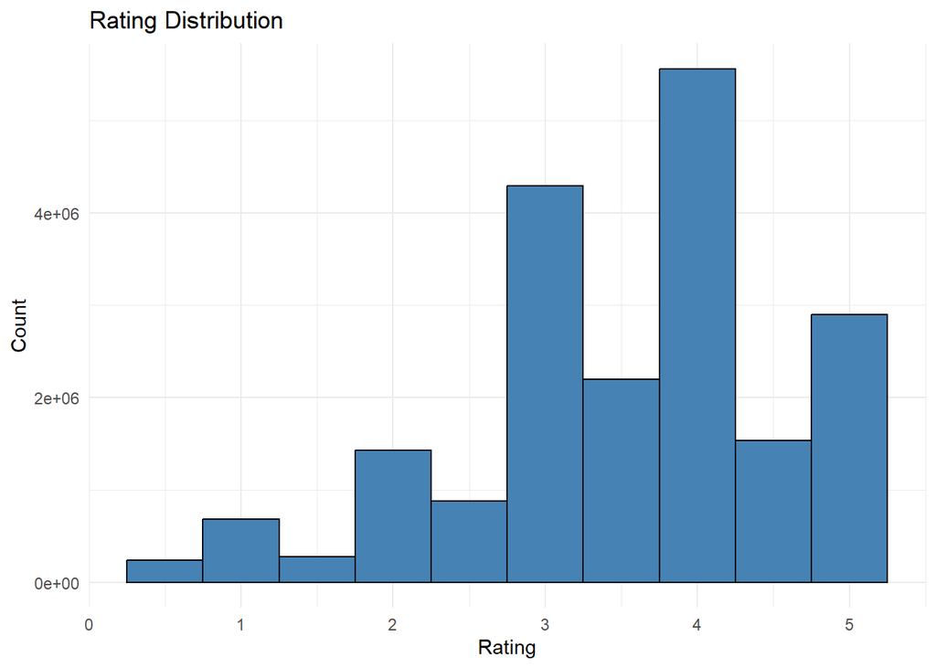

```r
# =========================================================
# 2. RATING DISTRIBUTION
# =========================================================
p1 <- ggplot(ratings, aes(x = rating)) +
  geom_histogram(binwidth = 0.5, fill = "steelblue", color = "black") +
  theme_minimal() +
  labs(title = "Rating Distribution", x = "Rating", y = "Count")

ggsave("Outputs/Figures/01_rating_distribution.png", p1, width = 6, height = 4)
print(p1)
```

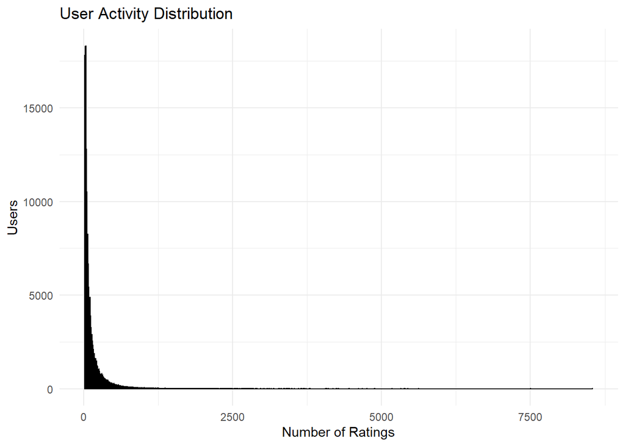

```r
# =========================================================
# 3. USER ACTIVITY
# =========================================================
user_activity <- ratings %>% count(userId)

p2 <- ggplot(user_activity, aes(x = n)) +
  geom_histogram(binwidth = 10, fill = "darkgreen", color = "black") +
  theme_minimal() +
  labs(title = "User Activity Distribution", x = "Number of Ratings", y = "Users")

ggsave("Outputs/Figures/02_user_activity.png", p2, width = 6, height = 4)
print(p2)
```

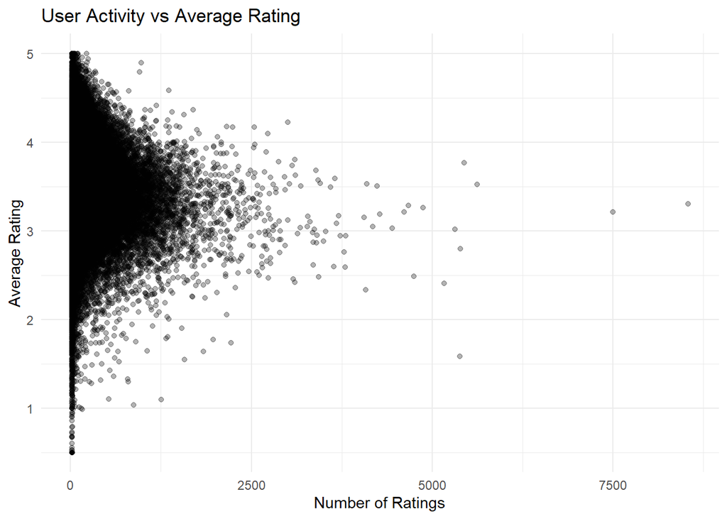

```r
# =========================================================
# 4. USER ACTIVITY VS AVG RATING
# =========================================================
user_stats <- ratings %>%
  group_by(userId) %>%
  summarise(
    n_ratings = n(),
    avg_rating = mean(rating),
    .groups = "drop"
  )

p3 <- ggplot(user_stats, aes(x = n_ratings, y = avg_rating)) +
  geom_point(alpha = 0.3) +
  theme_minimal() +
  labs(title = "User Activity vs Average Rating",
       x = "Number of Ratings",
       y = "Average Rating")

ggsave("Outputs/Figures/03_user_activity_vs_rating.png", p3, width = 7, height = 5)
print(p3)
```

```r
# =========================================================
# 5. MOVIE POPULARITY
# =========================================================
movie_popularity <- ratings %>%
  count(movieId) %>%
  arrange(desc(n)) %>%
  head(10) %>%
  left_join(movies, by = "movieId")

cat("\n===== TOP 10 MOST RATED MOVIES =====\n")
```

```
##
## ===== TOP 10 MOST RATED MOVIES =====
```

```r
print(movie_popularity[, c("title", "n")])
```

```
##                                         title     n
##                                        <char> <int>
##  1:                       Pulp Fiction (1994) 67310
##  2:                       Forrest Gump (1994) 66172
##  3:          Shawshank Redemption, The (1994) 63366
##  4:          Silence of the Lambs, The (1991) 63299
##  5:                      Jurassic Park (1993) 59715
##  6: Star Wars: Episode IV - A New Hope (1977) 54502
##  7:                         Braveheart (1995) 53769
##  8:         Terminator 2: Judgment Day (1991) 52244
##  9:                        Matrix, The (1999) 51334
## 10:                   Schindler's List (1993) 50054
```

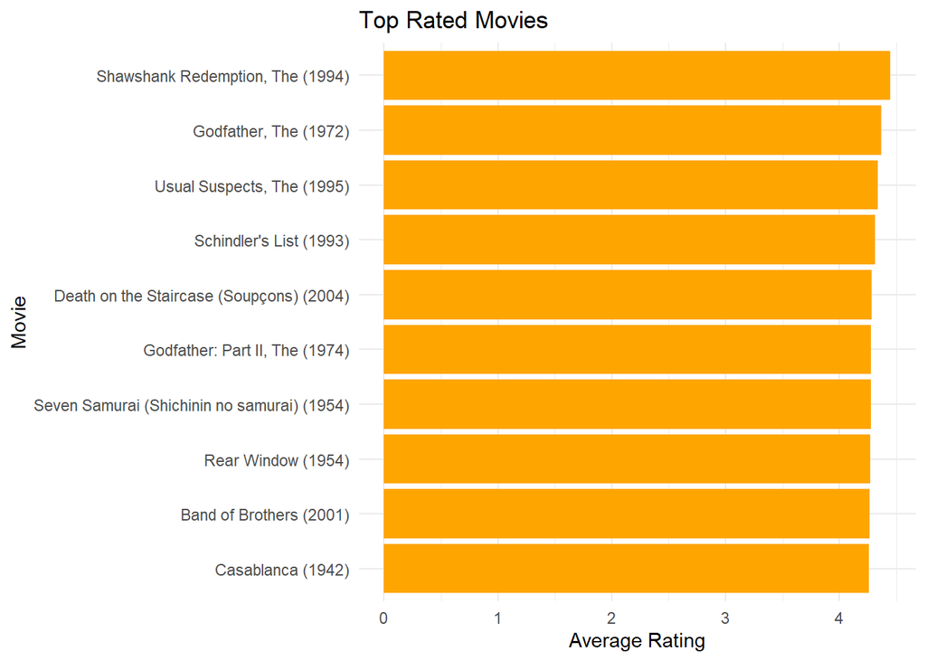

```r
write.csv(movie_popularity, "Outputs/Tables/movie_popularity.csv", row.names = FALSE)

# =========================================================
# 6. TOP RATED MOVIES
# =========================================================
top_rated <- ratings %>%
  group_by(movieId) %>%
  summarise(
    avg_rating = mean(rating),
    count = n(),
    .groups = "drop"
  ) %>%
  filter(count >= 20) %>%
  arrange(desc(avg_rating)) %>%
  head(10) %>%
  left_join(movies, by = "movieId")

p4 <- ggplot(top_rated, aes(x = reorder(title, avg_rating), y = avg_rating)) +
  geom_bar(stat = "identity", fill = "orange") +
  coord_flip() +
  theme_minimal() +
  labs(title = "Top Rated Movies", x = "Movie", y = "Average Rating")

ggsave("Outputs/Figures/04_top_rated_movies.png", p4, width = 7, height = 5)
print(p4)
```

```r
# =========================================================
# 7. SPARSITY
# =========================================================
n_users  <- as.numeric(n_distinct(ratings$userId))
n_movies <- as.numeric(n_distinct(ratings$movieId))
n_ratings <- as.numeric(nrow(ratings))

cat("DEBUG TYPES:\n")
```

```
## DEBUG TYPES:
```

```r
cat("n_users:", n_users, typeof(n_users), "\n")
```

```
## n_users: 138493 double
```

```r
cat("n_movies:", n_movies, typeof(n_movies), "\n")
```

```
## n_movies: 18345 double
```

```r
cat("n_ratings:", n_ratings, typeof(n_ratings), "\n")
```

```
## n_ratings: 19984024 double
```

```r
# HARD CHECK
if (any(is.na(c(n_users, n_movies, n_ratings)))) {
  stop("NA detected in counts — data issue")
}

total_possible <- n_users * n_movies

cat("Total possible:", total_possible, "\n")
```

```
## Total possible: 2540654085
```

```r
if (is.na(total_possible) || total_possible <= 0) {
  stop("Invalid total_possible")
}

sparsity <- 1 - (n_ratings / total_possible)

cat("\n===== SPARSITY =====\n")
```

```
##
## ===== SPARSITY =====
```

```r
cat("Sparsity:", round(sparsity, 8), "\n")
```

```
## Sparsity: 0.9921343
```

```r
# =========================================================
# SAVE SUMMARY
# =========================================================
summary_table <- data.frame(
  Users = n_users,
  Movies = n_movies,
  Ratings = nrow(ratings),
  Sparsity = sparsity
)

write.csv(summary_table, "Outputs/Tables/eda_summary.csv", row.names = FALSE)
```

# 3. User-Item Matrix & Data Splitting

```r
# =========================================================
# LOAD LIBRARIES
# =========================================================
library(recommenderlab)
library(Matrix)
library(tidyverse)

# =========================================================
# LOAD CLEAN DATA
# =========================================================
ratings <- readRDS("Data/Processed/ratings_clean.rds")

# =========================================================
# GLOBAL CLEAN
# =========================================================
ratings <- ratings %>%
  filter(!is.na(userId), !is.na(movieId), !is.na(rating))

# =========================================================
# CREATE USER–ITEM MATRIX (SPARSE)
# =========================================================

# Convert userId & movieId to index
user_index  <- as.numeric(factor(ratings$userId))
movie_index <- as.numeric(factor(ratings$movieId))

# Build sparse matrix
rating_matrix <- sparseMatrix(
  i = user_index,
  j = movie_index,
  x = ratings$rating
)

cat("Matrix Dimension:\n")
```

```
## Matrix Dimension:
```

```r
cat("Users:", nrow(rating_matrix), "\n")
```

```
## Users: 138493
```

```r
cat("Movies:", ncol(rating_matrix), "\n")
```

```
## Movies: 18345
```

```r
# =========================================================
# CONVERT TO recommenderlab FORMAT
# =========================================================
rating_rrm <- as(rating_matrix, "realRatingMatrix")

cat("\nRealRatingMatrix Summary:\n")
```

```
##
## RealRatingMatrix Summary:
```

```r
rating_rrm
```

```
## 138493 x 18345 rating matrix of class 'realRatingMatrix' with 19984024 ratings.
```

```r
# =========================================================
# TRAIN–TEST SPLIT
# =========================================================
set.seed(123)

eval_scheme <- evaluationScheme(
  data = rating_rrm,
  method = "split",
  train = 0.8,
  given = 10,
  goodRating = 4
)

cat("\nEvaluation Scheme Created\n")
```

```
##
## Evaluation Scheme Created
```

```r
# =========================================================
# EXTRACT TRAIN & TEST DATA
# =========================================================
train_data <- getData(eval_scheme, "train")
known_data <- getData(eval_scheme, "known")
unknown_data <- getData(eval_scheme, "unknown")

cat("\nTrain/Test Split Summary:\n")
```

```
##
## Train/Test Split Summary:
```

```r
train_data
```

```
## 110794 x 18345 rating matrix of class 'realRatingMatrix' with 15977054 ratings.
```

```r
known_data
```

```
## 27699 x 18345 rating matrix of class 'realRatingMatrix' with 277091 ratings.
```

```r
unknown_data
```

```
## 27699 x 18345 rating matrix of class 'realRatingMatrix' with 3729879 ratings.
```

```r
# =========================================================
# SAVE OBJECTS
# =========================================================
saveRDS(rating_rrm, "Data/Processed/rating_matrix.rds")
saveRDS(eval_scheme, "Data/Processed/eval_scheme.rds")
```

# 4. Modeling and Recommendation System

```r
library(recommenderlab)

# =========================================================
# 1. LOAD DATA
# =========================================================
eval_scheme <- readRDS("Data/Processed/eval_scheme.rds")

train <- getData(eval_scheme, "train")
known   <- getData(eval_scheme, "known")
unknown <- getData(eval_scheme, "unknown")

n <- min(100, nrow(known))

known_small   <- known[1:n, ]
unknown_small <- unknown[1:n, ]

# =========================================================
# 2. MODELS
# =========================================================

# POPULAR
model_pop <- Recommender(train, method = "POPULAR")

# MATRIX FACTORIZATION (LIBMF / fallback SVD)
model_mf <- tryCatch({
  Recommender(train, method = "LIBMF",
              parameter = list(dim = 10, iter = 30, lambda = 0.01))
}, error = function(e) {
  Recommender(train, method = "SVD", parameter = list(k = 10))
})
```

```
## Available parameter (with default values):
## dim   =  10
## costp_l2  =  0.01
## costq_l2  =  0.01
## nthread   =  1
## verbose   =  FALSE
```

```r
# KNN (IBCF - reduced size for stability)
train_small <- train[1:min(500, nrow(train)), ]

model_knn <- Recommender(
  train_small,
  method = "IBCF",
  parameter = list(k = 30)
)

# =========================================================
# 3. PREDICTIONS
# =========================================================
pred_pop <- predict(model_pop, known_small, n = 10)
pred_mf  <- predict(model_mf,  known_small, n = 10)
pred_knn <- predict(model_knn, known_small, n = 10)

# =========================================================
# 4. GROUND TRUTH
# =========================================================
get_actual <- function(test_data) {

  lapply(1:nrow(test_data), function(i) {

    user <- as(test_data[i, ], "list")[[1]]

    if (length(user) == 0) return(character(0))

    names(user[user > 0])
  })
}

actual <- lapply(1:nrow(unknown_small), function(i) {

  user <- as(unknown_small[i, ], "list")[[1]]

  if (length(user) == 0) return(character(0))

  names(user)
})

# =========================================================
# 5. METRICS
# =========================================================

recall_at_k <- function(pred, actual, k = 10) {

  pred_list <- as(pred, "list")
  scores <- c()

  for (i in seq_along(pred_list)) {

    if (i > length(actual)) break

    p <- pred_list[[i]][1:k]
    a <- actual[[i]]

    if (length(a) == 0) next

    hits <- length(intersect(p, a))
    scores <- c(scores, hits / length(a))
  }

  if (length(scores) == 0) return(0)
  mean(scores)
}

map_at_k <- function(pred, actual, k = 10) {

  pred_list <- as(pred, "list")
  ap <- c()

  for (i in seq_along(pred_list)) {

    if (i > length(actual)) break

    p <- pred_list[[i]][1:k]
    a <- actual[[i]]

    if (length(a) == 0) next

    hit <- 0
    sum_prec <- 0

    for (j in seq_along(p)) {
      if (p[j] %in% a) {
        hit <- hit + 1
        sum_prec <- sum_prec + hit / j
      }
    }

    if (hit > 0) {
      ap <- c(ap, sum_prec / min(length(a), k))
    }
  }

  if (length(ap) == 0) return(0)
  mean(ap)
}

dcg <- function(rel) {
  sum(rel / log2(seq_along(rel) + 1))
}

ndcg_at_k <- function(pred, actual, k = 10) {

  pred_list <- as(pred, "list")
  scores <- c()

  for (i in seq_along(pred_list)) {

    if (i > length(actual)) break

    p <- pred_list[[i]][1:k]
    a <- actual[[i]]

    if (length(a) == 0) next

    rel <- as.numeric(p %in% a)
    ideal <- sort(rel, decreasing = TRUE)

    dcg_val <- dcg(rel)
    idcg_val <- dcg(ideal)

    if (idcg_val == 0) next

    scores <- c(scores, dcg_val / idcg_val)
  }

  if (length(scores) == 0) return(0)
  mean(scores)
}

# =========================================================
# 6. EVALUATION RESULTS
# =========================================================
results <- data.frame(
  model = c("POPULAR", "MF", "KNN (IBCF)"),

  recall_at_10 = c(
    recall_at_k(pred_pop, actual),
    recall_at_k(pred_mf, actual),
    recall_at_k(pred_knn, actual)
  ),

  map_at_10 = c(
    map_at_k(pred_pop, actual),
    map_at_k(pred_mf, actual),
    map_at_k(pred_knn, actual)
  ),

  ndcg_at_10 = c(
    ndcg_at_k(pred_pop, actual),
    ndcg_at_k(pred_mf, actual),
    ndcg_at_k(pred_knn, actual)
  )
)

print(results)
```

```
##        model recall_at_10  map_at_10 ndcg_at_10
## 1    POPULAR 0.0462504045 0.32186161  0.7349066
## 2         MF 0.0028283343 0.12848485  0.5840892
## 3 KNN (IBCF) 0.0006809529 0.06201058  0.5383919
```

```r
# =========================================================
# 7. SAVE OUTPUT
# =========================================================
saveRDS(model_pop, "Outputs/Models/popular.rds")
saveRDS(model_mf,  "Outputs/Models/mf.rds")
saveRDS(model_knn, "Outputs/Models/knn_ibcf.rds")

write.csv(results,
          "Outputs/Tables/model_results.csv",
          row.names = FALSE)
```

# 5. MODEL COMPARISON VISUALIZATION

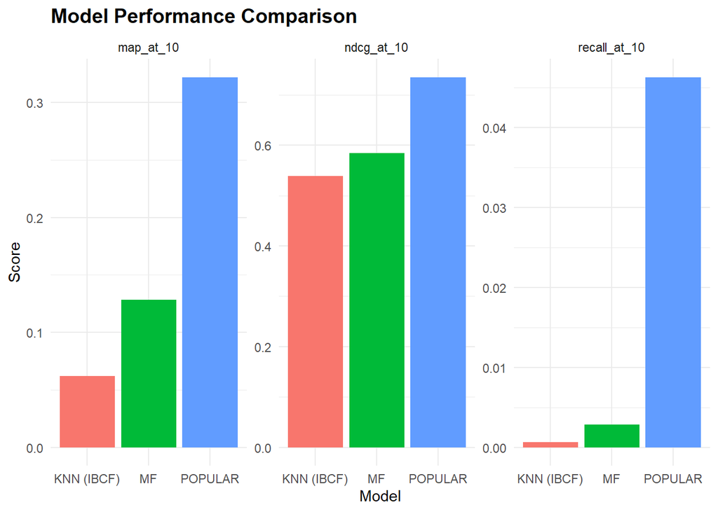

```r
library(ggplot2)
library(tidyr)
library(dplyr)

# =========================================================
# 1. LOAD RESULTS
# =========================================================
# results <- read.csv("Outputs/Tables/model_results.csv")

# =========================================================
# 2. RESHAPE DATA
# =========================================================
results_long <- results %>%
  pivot_longer(
    cols = -model,
    names_to = "metric",
    values_to = "value"
  )

# =========================================================
# 3. VISUALIZATION
# =========================================================
plot_model <- ggplot(results_long,
                     aes(x = model, y = value, fill = model)) +
  geom_bar(stat = "identity", position = "dodge") +
  facet_wrap(~metric, scales = "free") +
  theme_minimal() +
  labs(
    title = "Model Performance Comparison",
    x = "Model",
    y = "Score"
  ) +
  theme(
    legend.position = "none",
    plot.title = element_text(size = 14, face = "bold")
  )

print(plot_model)
```

```r
# =========================================================
# 4. SAVE PLOT
# =========================================================
ggsave(
  "Outputs/Figures/model_comparison.png",
  plot_model,
  width = 8,
  height = 5
)
```

# Conclusion & Insights

## 1. Summary of Findings

- **Recommendation System Evaluation:**
  - Three models were evaluated: POPULAR, Matrix Factorization (MF), and K-Nearest Neighbors (KNN).
  - Evaluation metrics used were Recall@10, MAP@10, and NDCG@10 to measure both retrieval quality and ranking performance.
  - The dataset shows a strong popularity bias, where a small number of frequently rated items dominate user preferences.
- **Model Performance:**
  - The POPULAR model achieved the best overall performance across all metrics, especially in MAP@10 and NDCG@10.
  - The MF model showed moderate performance but was limited by data sparsity and insufficient interaction density.
  - The KNN (IBCF) model performed the weakest, indicating that user-item similarity is not stable in sparse conditions.
- **Evaluation Insights:**
  - Recall@10 values are relatively low, which is expected in recommender systems with a large item space.
  - MAP@10 and NDCG@10 provide better insight into ranking quality, showing that POPULAR consistently ranks relevant items higher.
  - Overall, simpler baseline models can outperform more complex models depending on dataset characteristics.

## 2. Practical Implications

- Popularity-based recommendation is highly effective in datasets with strong item popularity bias.
- Matrix Factorization is more suitable when user-item interactions are denser and more balanced.
- KNN-based collaborative filtering is sensitive to sparsity and may not perform well without sufficient data.
- In real-world systems, baseline models like POPULAR remain strong benchmarks and should not be ignored.

## 3. Recommendations

- For production systems with sparse data, start with a **POPULAR baseline** as a strong benchmark.
- Improve MF performance by tuning hyperparameters (latent factors, regularization, iterations).
- Consider hybrid recommendation approaches (e.g., combining POPULAR + MF) to improve robustness.
- Collect more interaction data to improve collaborative filtering performance, especially for KNN-based models.